# Classification_Redkokosh

Redkokosh Kirill

5/23/2022

Прочитаем набор данных.

```r
data <- Auto
head(data)
```

```
##   mpg cylinders displacement horsepower weight acceleration year origin
## 1  18         8          307        130   3504         12.0   70      1
## 2  15         8          350        165   3693         11.5   70      1
## 3  18         8          318        150   3436         11.0   70      1
## 4  16         8          304        150   3433         12.0   70      1
## 5  17         8          302        140   3449         10.5   70      1
## 6  15         8          429        198   4341         10.0   70      1
##                        name
## 1 chevrolet chevelle malibu
## 2         buick skylark 320
## 3        plymouth satellite
## 4             amc rebel sst
## 5               ford torino
## 6          ford galaxie 500
```

Вывели первые шесть строк.

```r
m <- median(data$mpg)
data <- data %>% mutate(mpg01 = as.factor(as.integer(mpg < m)))
head(data)
```

```
##   mpg cylinders displacement horsepower weight acceleration year origin
## 1  18         8          307        130   3504         12.0   70      1
## 2  15         8          350        165   3693         11.5   70      1
## 3  18         8          318        150   3436         11.0   70      1
## 4  16         8          304        150   3433         12.0   70      1
## 5  17         8          302        140   3449         10.5   70      1
## 6  15         8          429        198   4341         10.0   70      1
##                        name mpg01
## 1 chevrolet chevelle malibu     1
## 2         buick skylark 320     1
## 3        plymouth satellite     1
## 4             amc rebel sst     1
## 5               ford torino     1
## 6          ford galaxie 500     1
```

Добавили новую переменную и вывели полученный датафрейм.

2. Explore the data graphically in order to investigate the association between mpg01 and the other features. Which of the other features seem most likely to be useful in predicting mpg01? Scatterplots and boxplots may be useful tools to answer this question. Describe your findings.

```r
summary(data[2:8])
```

```
##    cylinders      displacement     horsepower        weight      acceleration
##  Min.   :3.000   Min.   : 68.0   Min.   : 46.0   Min.   :1613   Min.   : 8.00
##  1st Qu.:4.000   1st Qu.:105.0   1st Qu.: 75.0   1st Qu.:2225   1st Qu.:13.78
##  Median :4.000   Median :151.0   Median : 93.5   Median :2804   Median :15.50
##  Mean   :5.472   Mean   :194.4   Mean   :104.5   Mean   :2978   Mean   :15.54
##  3rd Qu.:8.000   3rd Qu.:275.8   3rd Qu.:126.0   3rd Qu.:3615   3rd Qu.:17.02
##  Max.   :8.000   Max.   :455.0   Max.   :230.0   Max.   :5140   Max.   :24.80
##       year           origin
##  Min.   :70.00   Min.   :1.000
##  1st Qu.:73.00   1st Qu.:1.000
##  Median :76.00   Median :1.000
##  Mean   :75.98   Mean   :1.577
##  3rd Qu.:79.00   3rd Qu.:2.000
##  Max.   :82.00   Max.   :3.000
```

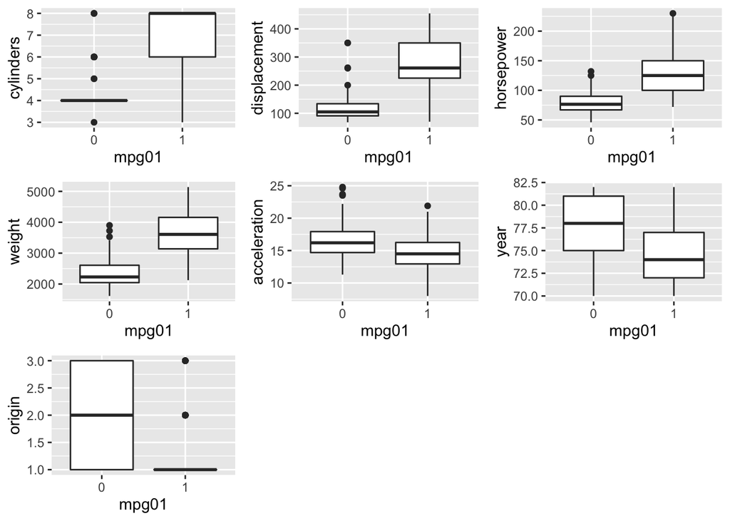

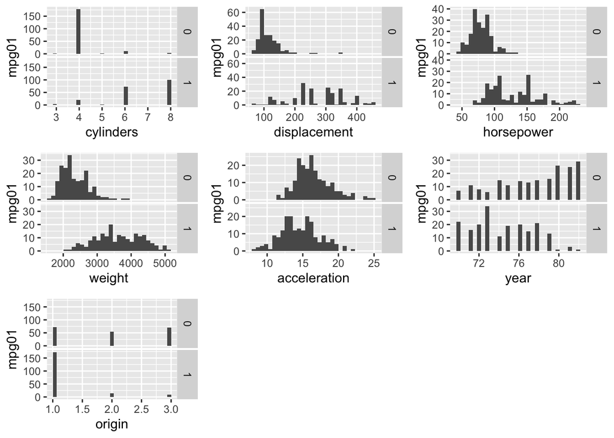

```r
gg <- ggpairs(data, title="correlogram", columns=c(2:8, 10), upper = list(continuous = "points"), diag = list(continuous = "barDiag"))
```

Наиболее значимыми кажутся различия внутри переменных cylinders, displacement, horsepower, weight и origin (при группировке по mpg01), при этом cylinders и origin– факторы, в дальнейшем будем использовать их в модели, но возможно, их влияение не будет значимым.

3. Split the data into a training set and a test set.

```r
split <- sample.split(data$mpg01, SplitRatio = 0.67)
dataTrain <- subset(data, split == "TRUE")
dataTest <- subset(data, split == "FALSE")
```

Разделили данные в соотношении 67/33.

6. Perform logistic regression on the training data in order to predict mpg01 using the variables that seemed most associated with mpg01 in (b). What is the test error of the model obtained?

```r
glm.fits <- glm(mpg01 ~ cylinders + displacement + horsepower + weight + origin, data = dataTrain, family = binomial)
summary(glm.fits)
```

```
##
## Call:
## glm(formula = mpg01 ~ cylinders + displacement + horsepower +
##     weight + origin, family = binomial, data = dataTrain)
##
## Deviance Residuals:
##     Min       1Q   Median       3Q      Max
## -3.3136  -0.3414  -0.0450   0.1697   2.3274
##
## Coefficients:
##                Estimate Std. Error z value Pr(>|z|)
## (Intercept)  -1.162e+01  2.054e+00  -5.656 1.55e-08 ***
## cylinders     3.878e-02  4.421e-01   0.088  0.93011
## displacement  9.581e-03  1.156e-02   0.829  0.40718
## horsepower    2.457e-02  1.802e-02   1.364  0.17264
## weight        2.694e-03  8.857e-04   3.041  0.00236 **
## origin       -1.353e-01  3.614e-01  -0.374  0.70807
## ---
## Signif. codes:  0 '***' 0.001 '**' 0.01 '*' 0.05 '.' 0.1 ' ' 1
##
## (Dispersion parameter for binomial family taken to be 1)
##
##     Null deviance: 363.21  on 261  degrees of freedom
## Residual deviance: 134.44  on 256  degrees of freedom
## AIC: 146.44
##
## Number of Fisher Scoring iterations: 7
```

```r
predict_reg <- predict(glm.fits, type = "response")
predict_reg <- ifelse(predict_reg > 0.5, 1, 0)
table(dataTrain$mpg01, predict_reg)
```

```
##    predict_reg
##       0   1
##   0 117  14
##   1  16 115
```

```r
mean(predict_reg == dataTrain$mpg01)
```

```
## [1] 0.8854962
```

```r
predict_reg <- predict(glm.fits, newdata = dataTest, type = "response")
predict_reg <- ifelse(predict_reg > 0.5, 1, 0)
table(dataTest$mpg01, predict_reg)
```

```
##    predict_reg
##      0  1
##   0 60  5
##   1  9 56
```

```r
mean(predict_reg == dataTest$mpg01)
```

```
## [1] 0.8923077
```